# Finding and accessing environmental data in R

ENS-215

10-Feb-2023

In today’s lecture we are going to learn how to make use of a number of R packages that allow you to directly query and access data from some notable environmental databases. These data access packages are incredibly powerful as they allow you to streamline your workflow by combining the data identification and acquisition steps directly with your data analysis. They also provide a highly efficient and reproducible approach to data identification and acquisition - allowing you to easily adapt or expand your research question with minimal additional effort.

There are many packages that have been developed for accessing data through R, including a wide range of packages for accessing environmental datasets. Today we will look at a few notable packages and in the coming weeks we will explore some additional ones. The packages below highlight a number of notable research-quality datasets that are likely to be useful in many of your class projects, theses, and future research/work.

Let’s load in a few packages that we will use today. It is likely that many of you may not yet have installed the `leaflet` package. If so, you should go ahead and do so before proceeding. FYI, the leaflet package allows you to make interactive maps. You will learn how to do this in the upcoming lectures, however a few of the packages used today will automatically generate leaflet maps and so you will need this package for those maps to be automatically generated.

```r
library(tidyverse)
library(lubridate)
library(leaflet)
```

## Climate data

In much of our environmental research we need to use climate/meteorological data. While there are a host of organization/agencies that provide freely available research quality datasets, locating and accessing the data can often be time-consuming and difficult. Furthermore, once you’ve located the data (generally through the website of the agency/organization collecting the data) you typically need to download the file (e.g., csv, Excel), load it into R, and reformat the data for your analysis. The R packages below allow you to quickly locate the data of interest and directly load it into R in a format that is ready to use in R - typically all within a single function call!

### GSODR package: access daily meteorological data from NOAA

The [**Global Surface Summary of the Day - GSOD**](https://www.ncei.noaa.gov/access/metadata/landing-page/bin/iso?id=gov.noaa.ncdc:C00516) is a dataset from the National Oceanic and Atmospheric Administration (NOAA) that provides daily average values for a range of meteorological variables (e.g., air temperature, precipitation, wind speed, barometric pressure) at thousands of locations around the globe. These daily average data are computed hourly observations at meteorological stations (i.e., they are actual observations and not model/simulation outputs) and the data goes back upwards of 90 years at some locations. FYI, the hourly data is available through the Integrated Surface Hourly (ISH) dataset from NOAA, which we will learn how to access later in today’s lecture.

We will learn how to use the [`GSODR` package](https://docs.ropensci.org/GSODR/) to directly access this data.

First let’s load in the package (FYI, you will need to install the package first if you have not installed it before)

```r
library(GSODR)
```

The package comes with a dataset that has all of the available meteorological stations and their location information/details (e.g., lat/long, country, state, period of data coverage). We will load in this data below.

```r
load(system.file("extdata", "isd_history.rda", package = "GSODR"))
```

Take a look at the `isd_history` data frame to familiarize yourself with what it contains. You’ll see that you could use this information to easily identify sites of interest to your particular research question. Below you can see a map of all of the available meteorological stations in the GSOD database.

[interactive chart not shown]

If you identified a station(s) of interest you can download the data using the `get_GSOD()` function. Let’s try this out for Windhoek, which is the capital of the country of Namibia (located in SW Africa). To download data for a given station, you need to supply the station ID (STNID) and the years of interest. You can locate the STNID in the `isd_history` data frame.

```r
met_df <- get_GSOD(years = 2022:2023, station = "681100-99999")
```

```
##
## This station, 681100-99999, only provides data for years 1957 to 2022.
```

Take a look at the `met_df` data frame. The description of the variables can [be found here](https://docs.ropensci.org/GSODR/articles/GSODR.html#appendices).

Let’s plot the a time-series of the daily minimum and maximum air temperatures from 2022-2023 at the selected met station.

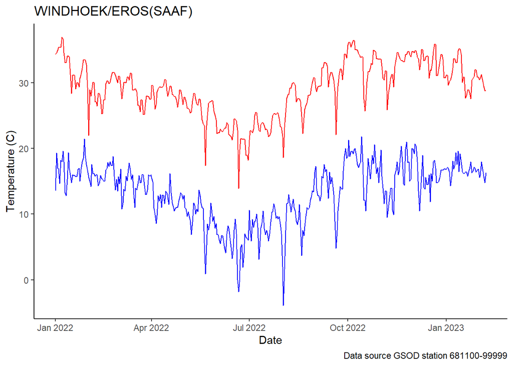

```r
met_df %>%
  ggplot() +
  geom_line(aes(x = YEARMODA, y = MIN), color = "blue") +
  geom_line(aes(x = YEARMODA, y = MAX), color = "red") +

  labs(title = met_df$NAME[1],
       x = "Date",
       y = "Temperature (C)",
       caption = paste("Data source GSOD station", met_df$STNID[1])
       ) +

  theme_classic()
```

Oftentimes you have a study location/area of interest and you would like to identify any/all meteorological stations that exist nearby your site. The `GSODR` package has a really helpful function, `nearest_stations()` that does this. You need to supply the lat/long of the area to query and the radial distance (in kilometers) from your search point. The function will then return a list of the STNID with the station info for all stations that fall within your search radius.

Let’s test this out by searching for all of the stations within 25 km of Schenectady.

```r
schdy_met_stations <- nearest_stations(LAT = 42.81,
                                  LON = -73.94,
                                  distance = 25)


schdy_met_stations
```

```
## [1] "744994-99999" "999999-14735" "725180-14735"
```

We can see that there are 3 meteorological stations within 25 km of Schenectady.

- Download the data from 2010-2015 for the stations nearby Schenectady
- Try downloading meteorological data for a location you are interested in. Create some figures and/or tables that provide insight into that locations meteorological conditions.

## worldmet: access hourly meteorological data from NOAA

In the section above, we learned how to use the `GSODR` package to retrieve daily meteorological data from thousands of meteorological stations around the globe. Now we will learn how to access the hourly data from NOAA’s Integrated Surface Database using the [`worldmet` package](https://davidcarslaw.github.io/worldmet/index.html). Note that this package is very similar to `GSODR` and in fact they access data from the same set of stations (with `GSODR` providing daily summaries and `worldmet` providing access to the hourly data).

Let’s load in the `worldmet` package. If you haven’t yet installed `worldmet` you will need to go ahead and do so first.

```r
library(worldmet)
```

The `worldmet` package is pretty straightforward to use - you simply need to specify the station you would like access and the year(s) you would like to download the data for.

We can use the `getMeta()` function to obtain a data frame containing information (e.g., station ID, name, lat/long,…) about each of the stations that have data available for download.

```r
worldmet_site_df <- getMeta(plot = F)
```

Take a look at the data frame you just obtained and you will see that the `code` column contains the station ID that is unique to each site. The data frame also has a bunch of additional useful information about each site, including the time period over which data is available.

Note that I set in the function call above I set the `plot` argument to false. If you set it equal to true (`T`), then an interactive map will be generated showing the location of all the sites. To have the map show up when you knit your document you will also need to set the `returnMap` argument to `T`. Let’s make a map of all of the available sites.

```r
getMeta(plot = T, returnMap = T)
```

[interactive chart not shown]

Ok, now we can go ahead and use the `importNOAA()` function to download some hourly meteorological data. This function requires two arguments. The `code` argument is where you specify the station ID. The year argument is where you specify the year(s) you would like to download. To specify multiple years you would set the years argument as follows `years = 2010:2022`, which in that case would download hourly data from 2010 through 2022.

Let’s go ahead and download hourly data for Albany International Airport (station code: 725180-14735) for 2022 through the most recent reported measurement (~ 1 or 2 days prior to today).

```r
worldmet_data <- importNOAA(code = "725180-14735",
                                      year = 2022:2023)
```

Descriptions of all the variables and their units are [available here](https://davidcarslaw.github.io/worldmet/reference/importNOAA.html)

**Important:** All data are reported in Greenwich Meantime (GMT) time zone format. This means that you may want to convert the time data to the stations local time zone.

Let’s quickly plot some of the data to see how it looks.

**Hourly temperature data**

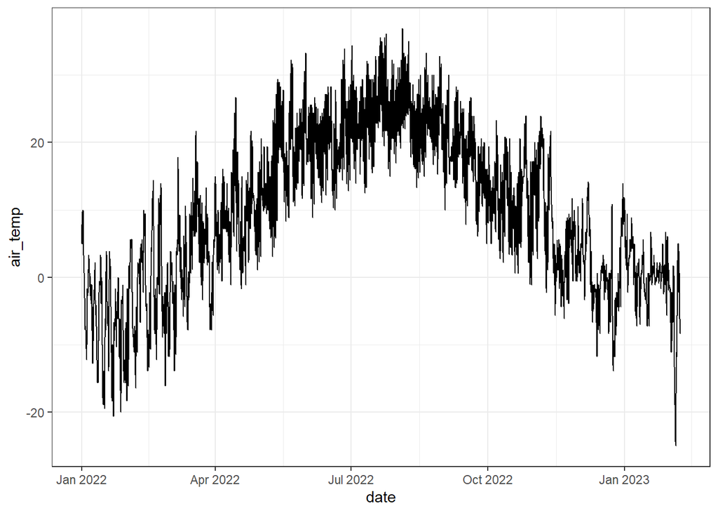

```r
worldmet_data %>%
  ggplot(aes(x = date, y = air_temp)) +
  geom_line() +

  theme_bw()
```

**Hourly relative humidity data**

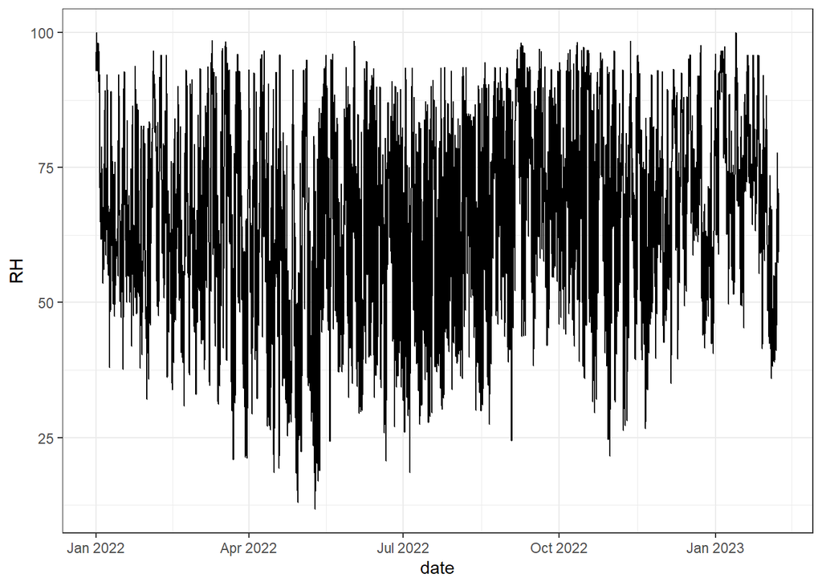

```r
worldmet_data %>%
  ggplot(aes(x = date, y = RH)) +
  geom_line() +

  theme_bw()
```

## Hydrological data using the `dataRetrieval` package

The USGS [National Water Information Service (NWIS)](https://waterdata.usgs.gov/nwis) is an incredible database containing physical and chemical data on the streams/rivers, lakes, and groundwater for nearly 2 million locations across the US and US territories. From NWIS you can download data related to thousands of different parameters including streamflow, groundwater levels, and a wide range of water chemistry and physical conditions.

This data can be queried and retrieved using the `dataRetrieval` package that was developed and is maintained by the USGS. Given the richness and volume of the data there are many functions and features within this package and some knowledge of how the available data is particularly helpful when using `dataRetrieval`. Today we’ll learn how to download daily streamflow data and also learn the basics of downloading water quality data. For those interested in learning more I am helping to provide additional guidance and you can also explore the excellent [background](http://usgs-r.github.io/dataRetrieval/articles/dataRetrieval.html) and [tutorial](http://usgs-r.github.io/dataRetrieval/articles/tutorial.html) articles that have been put together by the developers of the package.

When querying the NWIS database to find and/or download available data you generally need to specify a parameter (i.e., what was being measured) and a location/region of interest.

If you already know the USGS site number (the unique numeric identifier the USGS assigns to sampling sites) and you know that the parameter of interest was measured at the site you can proceed to the data acquisition step. However, many times we don’t know what/if available sites with the desired data exist and we need to first identify those sites. Once you’ve identified the sites with the desired data, you can then directly acquire the data for the site(s) of interest.

Let’s work through an example where we locate sites in Schenectady county that have mean daily streamflow and/or gauge height (i.e., stream water level) data. Note that we could look for other parameters (e.g., turbidity, concentration of chloride, pH,…) if we were interested in those measurements.

First let’s load in the `dataRetrieval` package. If you have never used this package before you will need to install it before proceeding.

```r
library(dataRetrieval)
```

### Identify sites with desired data

We are going to query the NWIS database for sites within Schenectady county (`countyCd = "36093"`) that have streamflow (00060) and/or gauge height (i.e., water level) (00065) data.

Note that every US county has a FIPS county code, which is a unique numeric code that the US has assigned to each county. You can find a list of all the [county codes here](https://help.waterdata.usgs.gov/code/county_query?fmt=html).

You can also find a list of all of the [parameter codes used by the USGS here](https://help.waterdata.usgs.gov/codes-and-parameters/parameters).

You’ll also note that we specified `service = "dv"`, this means to query for sites that have daily data reported.

```r
sites_schdy <- whatNWISsites(countyCd = "36093",
                             parameterCd = c("00060","00065"),
                             service = "dv"
                             )


sites_schdy
```

|  | agency_cd | site_no | station_nm | site_tp_cd | dec_lat_va | dec_long_va | colocated | queryTime |
| --- | --- | --- | --- | --- | --- | --- | --- | --- |
| 1 | USGS | 01351500 | SCHOHARIE CREEK AT BURTONSVILLE NY | ST | 42.80003 | -74.26278 | FALSE | 2023-02-09 12:29:34 |
| 2 | USGS | 01351450 | SCHOHARIE CREEK AT ESPERANCE NY | ST | 42.76058 | -74.25478 | FALSE | 2023-02-09 12:29:34 |
| 3 | USGS | 01354230 | MOHAWK RIVER AT LOCK 9 AT ROTTERDAM JUNCTION NY | ST | 42.87828 | -74.04075 | FALSE | 2023-02-09 12:29:34 |
| 4 | USGS | 01354330 | MOHAWK RIVER AT LOCK 8 NEAR SCHENECTADY NY | ST | 42.82816 | -73.99037 | FALSE | 2023-02-09 12:29:34 |
| 5 | USGS | 01354490 | MOHAWK RIVER AT SCHENECTADY NY | ST | 42.81980 | -73.94929 | FALSE | 2023-02-09 12:29:34 |
| 6 | USGS | 01354500 | MOHAWK RIVER AT FREEMAN'S BRIDGE AT SCHENECTADY NY | ST | 42.83053 | -73.93075 | FALSE | 2023-02-09 12:29:34 |
| 7 | USGS | 01356190 | LISHA KILL NORTHWEST OF NISKAYUNA NY | ST | 42.78361 | -73.85667 | FALSE | 2023-02-09 12:29:34 |
| 8 | USGS | 01356200 | LISHA KILL AT NISKAYUNA NY | ST | 42.79174 | -73.84734 | FALSE | 2023-02-09 12:29:34 |

You can see that there are 8 sites that meet the search criteria. You’ll also note that under the `site_tp_cd` column you see *ST*, which stand for stream. If you queried for a parameter (e.g., water temperature) that could also apply to other site types, then you would likely see other `site_tp_cd` values listed too (e.g., *GW*).

Now let’s get information about the available data (e.g., the number of observations, the length of the data record).

```r
sites_what_data <- whatNWISdata(siteNumber = sites_schdy$site_no,
                            service = "dv",
                            parameterCd = c("00060","00065"),
                            statCd = "00003")

sites_what_data
```

|  | agency_cd | site_no | station_nm | site_tp_cd | dec_lat_va | dec_long_va | coord_acy_cd | dec_coord_datum_cd | alt_va | alt_acy_va | alt_datum_cd | huc_cd | data_type_cd | parm_cd | stat_cd | ts_id | loc_web_ds | medium_grp_cd | parm_grp_cd | srs_id | access_cd | begin_date | end_date | count_nu |
| --- | --- | --- | --- | --- | --- | --- | --- | --- | --- | --- | --- | --- | --- | --- | --- | --- | --- | --- | --- | --- | --- | --- | --- | --- |
| 2 | USGS | 01351450 | SCHOHARIE CREEK AT ESPERANCE NY | ST | 42.76058 | -74.25478 | 1 | NAD83 | 551.31 | 0.01 | NAVD88 | 02020005 | dv | 00065 | 00003 | 237107 | NA | wat | NA | 17164583 | 0 | 2017-12-03 | 2023-02-08 | 1870 |
| 347 | USGS | 01351500 | SCHOHARIE CREEK AT BURTONSVILLE NY | ST | 42.80003 | -74.26278 | 1 | NAD83 | 507.44 | 0.01 | NAVD88 | 02020005 | dv | 00060 | 00003 | 105043 | NA | wat | NA | 1645423 | 0 | 1939-10-01 | 2023-02-08 | 30447 |
| 614 | USGS | 01354230 | MOHAWK RIVER AT LOCK 9 AT ROTTERDAM JUNCTION NY | ST | 42.87828 | -74.04075 | 1 | NAD83 | NA | NA | NA | 02020004 | dv | 00065 | 00003 | 265679 | NA | wat | NA | 17164583 | 0 | 2019-12-12 | 2023-02-08 | 1098 |
| 618 | USGS | 01354330 | MOHAWK RIVER AT LOCK 8 NEAR SCHENECTADY NY | ST | 42.82816 | -73.99037 | H | NAD83 | 199.46 | 0.01 | NAVD88 | 02020004 | dv | 00065 | 00003 | 105047 | NA | wat | NA | 17164583 | 0 | 2011-12-14 | 2023-02-08 | 4066 |
| 741 | USGS | 01354500 | MOHAWK RIVER AT FREEMAN'S BRIDGE AT SCHENECTADY NY | ST | 42.83053 | -73.93075 | 1 | NAD83 | 199.46 | 0.01 | NAVD88 | 02020004 | dv | 00060 | 00003 | 292954 | NA | wat | NA | 1645423 | 0 | 2011-08-06 | 2023-02-08 | 4203 |
| 749 | USGS | 01356190 | LISHA KILL NORTHWEST OF NISKAYUNA NY | ST | 42.78361 | -73.85667 | S | NAD83 | 238.78 | 0.01 | NGVD29 | 02020004 | dv | 00060 | 00003 | 105052 | NA | wat | NA | 1645423 | 0 | 1993-08-26 | 2012-09-29 | 5878 |

In the above function call you see that we set the argument `statCd = "00003"`. This specifies the statistic to download. The code `00003` means to obtain the average value. We need to specify this since we are downloading daily values and since most sites take sub-hourly readings we need to tell the function what type of daily value to return (e.g., minimum measurement, maximum, average,…). If you want to obtain a different statistic than the average you can simply change the statistic code.

You can find a list of [USGS statistic codes here](https://help.waterdata.usgs.gov/stat_code).

We can see that we have information about the data records for the sites with available gauge height (parm_cd = 00065) and streamflow (parm_cd = 00060). Below is a map of these sites.

[interactive chart not shown]

Based on this information you might choose to acquire the data for some or all of these sites. Since there are only a few sites, let’s go ahead and download the water gauge height and streamflow data for all of these sites.

```r
df_stream_data <- readNWISdv(siteNumbers = sites_what_data$site_no,
                             parameterCd = c("00060","00065"),
                             statCd = "00003")
```

When you download the data it will have column names that refer to parameter codes and other data descriptors that are not particularly human readable. Let’s use the `renameNWISColumns()` function, which renames the columns with more human readable names.

```r
df_stream_data <- df_stream_data %>%
  renameNWISColumns()
```

Now let’s plot a time-series of the gauge heights for each of the sites.

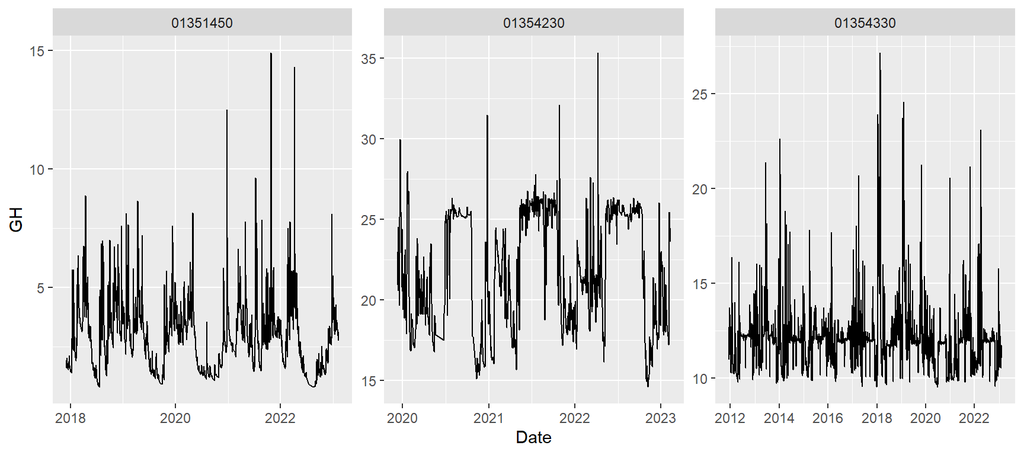

```r
df_stream_data %>%
  filter(!is.na(GH)) %>% # remove NA gauge heights

  ggplot(aes(x =Date, y = GH)) +
  geom_line() +

  facet_wrap(~ site_no, scales = "free")
```

Now let’s plot a time-series of the streamflow for each of the sites.

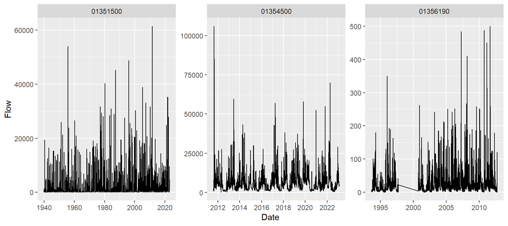

```r
df_stream_data %>%
  filter(!is.na(Flow)) %>%

  ggplot(aes(x =Date, y = Flow)) +
  geom_line() +

  facet_wrap(~ site_no, scales = "free")
```

### Water quality example

The NWIS database has over 4.4 million water quality measurements across hundreds of thousands of locations throughout the US and US territories. We can use the `dataRetrieval` package to query and access this data. Furthermore, the `dataRetrieval` package also allows us to access water quality data from the Environmental Protection Agency (EPA) and the US Department of Agriculture (USDA). As noted earlier, the `dataRetrieval` package and understanding NWIS data can take a bit of time to learn, though we’ll work through an example to highlight just how powerful `dataRetrieval` is for obtaining research grade water quality measurements.

The key first step is to specify what water quality parameter(s) you are interested in obtaining. You can find the list of the available [USGS parameter codes here](https://help.waterdata.usgs.gov/codes-and-parameters/parameters).

You can also obtain a data frame of the USGS, EPA, and USDA parameter codes directly in R, by calling `parameterCdFile`. Let’s do that now.

```r
parm_cd_df <- parameterCdFile
```

Take a look at this data frame. You’ll see that there are more than 24,000 parameter codes! You’ll see that each parameter code is assigned to one 16 different groups (e.g., physical, microbiological, nutrient,…). This makes it easier to located parameters by their group/type. You’ll also see that the full name and the units associated with each parameter are reported in the data frame.

Let’s go ahead and obtain data for **Nitrate, water, filtered, milligrams per liter as nitrogen** which is parameter code (00618).

Since there are likely 10’s or hundreds of thousands on nitrate measurements in the NWIS database we are going to limit our query by location and by date.

Let’s use the `whatWQPdata()` function to find out what data is available for nitrate (see the `parameterCd` argument) in New York state (see the `stateCd` argument). We will limit our query to sites that have at least some measurements that were collected after 1-Jan-2015 (see the `startDate` argument). Note that the sites can have data collected before that date, however they must have at least one measurement after that date in order to satisfy our search criteria.

Note that we are filtering the data so that we only keep groundwater sites (i.e., wells and springs).

```r
pCode <- c("00618")

NY_NO3_sites <- whatWQPdata(stateCd = "NY",
                            parameterCd = pCode,
                            startDate = "2015-01-01"
                            ) %>%

  filter(ResolvedMonitoringLocationTypeName %in% c("Well", "Spring"))
```

Take a look at the `NY_NO3_sites` data frame. You’ll see that this data frame has information on all of the available data based on the above query. You’ll see that each row represents a site with data. The last three columns of this data frame are particularly useful - they contain the date of the first (`begin_date`), last (`end_date`) measurement, and the number of total measurements for that site (`count_nu`). You’ll see that some sites have multiple measurements, indicating that samples were collected on a number of different dates/times.

Now, we will use the `readWQPqw()` function to acquire the data for the sites we have identified.

To do this we need to specify a site(s) to obtain. We do this by providing the `siteNumbers` argument with a vector of sites numbers.

We also need to specify the time period for the measurements we would like to obtain. We will limit ourselves to only downloading measurements that were taken from 1-Jan-2015 onward (see the `startDate` argument).

We also need to specify the parameter to download. Since we are interested in nitrate data we set the `parameterCd` argument to be equal to the nitrate parameter code of interest (i.e., 00618).

```r
NY_NO3_recent_data <- readWQPqw(siteNumbers = NY_NO3_sites$MonitoringLocationIdentifier,
                                parameterCd = pCode,
                                startDate = "2015-01-01"
                                )
```

Now we’ve downloaded the data - take a look at the data frame. You’ll see the measurement values in the `ResultMeasureValue` column.

Recall that some sites have multiple measurements (since measurements were taken on a number of different dates/times). Let’s summarize our data so that we can get the maximum nitrate concentration observed at each of the sites.

To do this we are going to group by `MonitoringLocationIdentifier` (i.e., group by the different sampling sites/locations) and then summarize the nitrate measurements to take the maximum value observed at each site.

```r
NY_NO3_recent_data_summary <- NY_NO3_recent_data %>%
  filter(!is.na(ResultMeasureValue)) %>%  # remove rows with NA values for the measurement of interest
  group_by(MonitoringLocationIdentifier) %>%
  summarize(NO3_max = max(ResultMeasureValue, na.rm = T)) %>%

  left_join(attr(NY_NO3_recent_data, "siteInfo")) # joining our water quality data with the data frame that contains site information
```

Take a look at this data frame to make sure you understand the steps above and what we have done.

Below is a map showing the data that we just summarized.

[interactive chart not shown]

We will learn how to make these types of maps in upcoming lectures.

## Exercises

Continue to experiment with the packages that we have learned how to use today. Think about how you might apply these packages to your final projects. Some possible things to explore include:

- Try obtaining daily or hourly meteorological data for site(s) that you are interested in.
- Compare meteorological conditions between sites of interest.
- Perform some of the time-series visualization/analysis approaches to the meteorological data.
- Use the `dataRetrieval` package to obtain data for additional parameters and sites from the NWIS data base. Spend some time exploring this data.